# American Airlines departure delay study case for Bankinter

Javier Cano Montero

26 de febrero de 2017

# Objective

In the present study case we will try to understand the reasons why departure delays occur for American Airlines in airports which operate 5000 or more of its flights and will focus on its worst performance airport (San Antonio).

# Summary

# Setting up the data

In this problem set we will use the data for the flights in 2016 that the Bureau of Transportation Statistics of the American Department of Transportation published on https://www.transtats.bts.gov/Tables.asp?DB_ID=120&DB_Name=Airline%20On-Time%20Performance%20Data&DB_Short_Name=On-Time.

First we will load the libraries and read the data. Because the data we are using is really heavy, two auxiliar functions have been provided to automatically download an unzip the data.

```r
# We load the libraries and the data required to run the script and generate this document.
rm(list=ls())
library(data.table)
library(dplyr)
library(tidyr)
library(ggplot2)
source("aux_functions.R")

# Uncomment to download and unzip data into data folder (may take a while)
# getData()
# Uncomment to merge monthly files into a yearly file (may take a while)
# mergeFiles()

perf <- fread("../data/On_Time_On_Time_Performance_2016_full.csv", header = T, data.table = FALSE, stringsAsFactors = T, showProgress = FALSE)
```

After reading the data, we will split it so we can focus on American Airlines and make comparisions with the other carriers performances.

```r
# Now we split the data so we can focus on American Airlines
# Data from AA
perf_aa <- filter(perf,Carrier=="AA")
perf_aa <- droplevels(perf_aa)
# Data from another carriers
perf <- filter(perf,Carrier!="AA")
perf <- droplevels(perf)
```

# Finding the airport with the most delay mean time

To understand why the departure delays happen, we will study big airports with 5000 or more departures during 2016. To achieve this goal we will calculate the mean of the following features:

- DepDelayMinutes: Difference in minutes between scheduled and actual departure time. Early departures set to 0.
- CarrierDelay: Carrier Delay, in Minutes.
- WeatherDelay: Weather Delay, in Minutes
- NASDelay: National Air System Delay, in Minutes.
- SecurityDelay: Security Delay, in Minutes.
- LateAircraftDelay: Late Aircraft Delay, in Minutes.

```r
# Departures by airport
# AA
departures_aa <-
  perf_aa %>%
  group_by(OriginCityName) %>%
  count()

departures_aa <-
  departures_aa %>%
  filter(n>5000)
# Others
departures_others <-
  perf %>%
  filter(OriginCityName %in% departures_aa$OriginCityName) %>%
  group_by(OriginCityName) %>%
  count()

# Informed departure delay
# AA
mean_delay_aa <-
  perf_aa %>%
  filter(!is.na(DepDelayMinutes) &
           DepDelayMinutes>0 &
           !is.na(CarrierDelay) &
           !is.na(WeatherDelay) &
           !is.na(NASDelay) &
           !is.na(SecurityDelay) &
           !is.na(LateAircraftDelay)
  ) %>%
  group_by(OriginCityName) %>%
  select(OriginCityName,DepDelayMinutes) %>%
  summarise_each(funs=c("mean","sd"))
# Others
mean_delay_others <-
  perf %>%
  filter(OriginCityName %in% departures_aa$OriginCityName &
           !is.na(DepDelayMinutes) &
           DepDelayMinutes>0 &
           !is.na(CarrierDelay) &
           !is.na(WeatherDelay) &
           !is.na(NASDelay) &
           !is.na(SecurityDelay) &
           !is.na(LateAircraftDelay)
  ) %>%
  group_by(OriginCityName) %>%
  select(OriginCityName,DepDelayMinutes) %>%
  summarise_each(funs=c("mean","sd"))

# Why is AA having delays?
delays_by_airport_aa <-
  perf_aa %>%
  filter(!is.na(DepDelayMinutes) &
           DepDelayMinutes>0 &
           !is.na(CarrierDelay) &
           !is.na(WeatherDelay) &
           !is.na(NASDelay) &
           !is.na(SecurityDelay) &
           !is.na(LateAircraftDelay)
  ) %>%
  group_by(OriginCityName) %>%
  select(OriginCityName,DepDelayMinutes,CarrierDelay,WeatherDelay,NASDelay,SecurityDelay,LateAircraftDelay) %>%
  summarise_each(funs=c("mean"))

# Why are the other carriers having delays?
delays_by_airport_others <-
  perf %>%
  filter(OriginCityName %in% departures_aa$OriginCityName &
           !is.na(DepDelayMinutes) &
           DepDelayMinutes>0 &
           !is.na(CarrierDelay) &
           !is.na(WeatherDelay) &
           !is.na(NASDelay) &
           !is.na(SecurityDelay) &
           !is.na(LateAircraftDelay)
  ) %>%
  group_by(OriginCityName) %>%
  select(OriginCityName,DepDelayMinutes,CarrierDelay,WeatherDelay,NASDelay,SecurityDelay,LateAircraftDelay) %>%
  summarise_each(funs=c("mean"))
```

Now that we have the KPI set we will arrange the airports so we can check the worst 10 with the most mean delayed departure minutes.

```r
# Let's join the number of departures with the reason of the delays
# AA
delays_by_airport_aa <-
  departures_aa %>%
  left_join(delays_by_airport_aa) %>%
  arrange(desc(DepDelayMinutes))

delays_by_airport_aa[is.na(delays_by_airport_aa)] <- 0

# Others
delays_by_airport_others <-
  departures_others %>%
  left_join(delays_by_airport_others)%>%
  arrange(desc(DepDelayMinutes))

delays_by_airport_others[is.na(delays_by_airport_others)] <- 0

print(delays_by_airport_aa)
```

```
## # A tibble: 34 × 8
##     OriginCityName     n DepDelayMinutes CarrierDelay WeatherDelay
##             <fctr> <int>           <dbl>        <dbl>        <dbl>
## 1  San Antonio, TX  5503        82.66512     30.67132    3.4651163
## 2       Newark, NJ  8431        80.90640     22.34975    3.2266010
## 3      Houston, TX  8081        80.08098     27.32488    6.7209756
## 4  New Orleans, LA  5602        77.61640     26.53968    2.7830688
## 5    St. Louis, MO  8235        77.37110     31.20062    3.5540541
## 6    Las Vegas, NV 15503        75.93706     31.93520    0.7631702
## 7   Pittsburgh, PA  5676        75.48373     39.39479    1.6355748
## 8       Denver, CO 10489        75.37061     29.49776    3.5514377
## 9      Detroit, MI  6365        75.11451     28.99433    4.0578231
## 10   Nashville, TN  5243        74.85294     24.93449    6.3676471
## # ... with 24 more rows, and 3 more variables: NASDelay <dbl>,
## #   SecurityDelay <dbl>, LateAircraftDelay <dbl>
```

```r
print(delays_by_airport_others)
```

```
## # A tibble: 34 × 8
##           OriginCityName      n DepDelayMinutes CarrierDelay WeatherDelay
##                   <fctr>  <int>           <dbl>        <dbl>        <dbl>
## 1              Miami, FL  15591        83.80553     23.06289     1.783675
## 2          Charlotte, NC  14641        81.36239     27.14750     3.983506
## 3           New York, NY 149386        78.21113     28.42072     4.256767
## 4            Detroit, MI 117594        75.34663     33.57298     3.447191
## 5  Dallas/Fort Worth, TX  55445        74.12542     31.56184     1.322379
## 6         Washington, DC  80874        73.48017     21.75354     4.968622
## 7       Philadelphia, PA  28791        73.33888     21.52424     2.704373
## 8             Newark, NJ 107352        72.74988     25.22163     3.380804
## 9            Orlando, FL 106647        69.61869     20.98702     3.664233
## 10    Raleigh/Durham, NC  26369        68.02225     22.24941     2.752683
## # ... with 24 more rows, and 3 more variables: NASDelay <dbl>,
## #   SecurityDelay <dbl>, LateAircraftDelay <dbl>
```

We can see that the worst airport for American Airlines is San Antonio in Texas with almost 83 minutes of delays to departure flights.

# Why is this happening?

To find the reason of these delays we will look for a how the features we set correlate among them. We suspect that the number of flights may have an influence on the delays. More number of flights may make the airport to run slower.

Let’s find out. First with the data of American Airlines.

```r
cor(delays_by_airport_aa[,2:3])[1,]
```

```
##               n DepDelayMinutes
##       1.0000000      -0.6399495
```

Now with the other carriers’ data.

```r
cor(delays_by_airport_others[,2:3])[1,]
```

```
##               n DepDelayMinutes
##       1.0000000      -0.1305447
```

We were wrong on our first try. As we can see on the previous correlations, the number of flights is negative correlated with de departure delay. This means that the more flights depart from an airport it suffers less departure delays. This is true also to the other carriers.

We will use the others features to find out the reasons after a departure delay. To do this we will run a linear regression with these features and the departure delay. Again, first with the data of American Airlines.

```r
x <- delays_by_airport_aa[,2:8]
summary(glm(data = x, DepDelayMinutes~.))
```

```
##
## Call:
## glm(formula = DepDelayMinutes ~ ., data = x)
##
## Deviance Residuals:
##     Min       1Q   Median       3Q      Max
## -2.2600  -0.6447   0.2189   0.7946   1.5848
##
## Coefficients:
##                     Estimate Std. Error t value Pr(>|t|)
## (Intercept)       -1.829e+00  3.520e+00  -0.519    0.608
## n                  2.791e-06  1.020e-05   0.274    0.786
## CarrierDelay       1.111e+00  5.361e-02  20.730  < 2e-16 ***
## WeatherDelay       7.847e-01  1.180e-01   6.649  3.9e-07 ***
## NASDelay           7.265e-01  9.891e-02   7.345  6.7e-08 ***
## SecurityDelay      2.452e+00  1.969e+00   1.245    0.224
## LateAircraftDelay  1.004e+00  4.902e-02  20.489  < 2e-16 ***
## ---
## Signif. codes:  0 '***' 0.001 '**' 0.01 '*' 0.05 '.' 0.1 ' ' 1
##
## (Dispersion parameter for gaussian family taken to be 1.49492)
##
##     Null deviance: 1791.135  on 33  degrees of freedom
## Residual deviance:   40.363  on 27  degrees of freedom
## AIC: 118.32
##
## Number of Fisher Scoring iterations: 2
```

As we can see, the delays induced by the carrier, the weather, tha NAS and a late aricraft are very significant to explain a departure delay. Since we can do nothing to change the weather or the reasons why the NAS delays a flight, we will work with the carrier delays and late aircrafts.

We will try and check if the distance of the flight is also significant to the delay, since long flights may take longer to get ready and take more time flying. To find out if this assumption is true, we will run some more regressions.

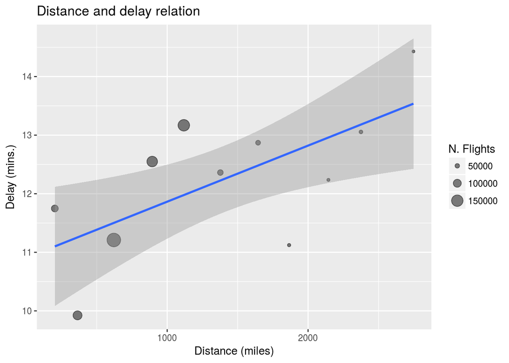

```r
delay <- summarise(perf_aa %>% group_by(DistanceGroup),
                   count = n(),
                   dist = mean(Distance, na.rm = TRUE),
                   delay = mean(DepDelayMinutes, na.rm=TRUE),
                   carrierDelay = mean(CarrierDelay, na.rm = TRUE),
                   lateCraft = mean(LateAircraftDelay,na.rm=TRUE)
                   )

ggplot(delay, aes(dist, delay)) +
  geom_point(aes(size = count), alpha = 1/2) +
  labs(x="Distance (miles)", y="Delay (mins.)") +
  geom_smooth(method = 'glm') +
  scale_size_area() +
  ggtitle("Distance and delay relation") +
  scale_radius(name="N. Flights")
```

In the previous plot, we can see that the distance is slightly positively correlated with a departure delay. Longer flights have a bit more departure delay.

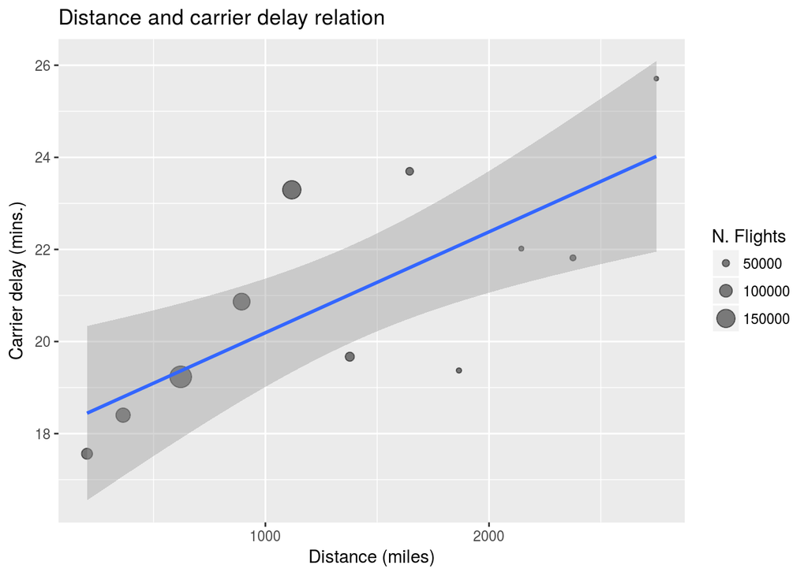

```r
ggplot(delay, aes(dist, carrierDelay)) +
  geom_point(aes(size = count), alpha = 1/2) +
  labs(x="Distance (miles)", y="Carrier delay (mins.)") +
  geom_smooth(method = 'glm') +
  scale_size_area() +
  ggtitle("Distance and carrier delay relation") +
  scale_radius(name="N. Flights")
```

In this plot, we can see that the delays caused by the carrier and the distance is again positively correlated. Longer flights are more delayed because of the carrier than shorter flights.

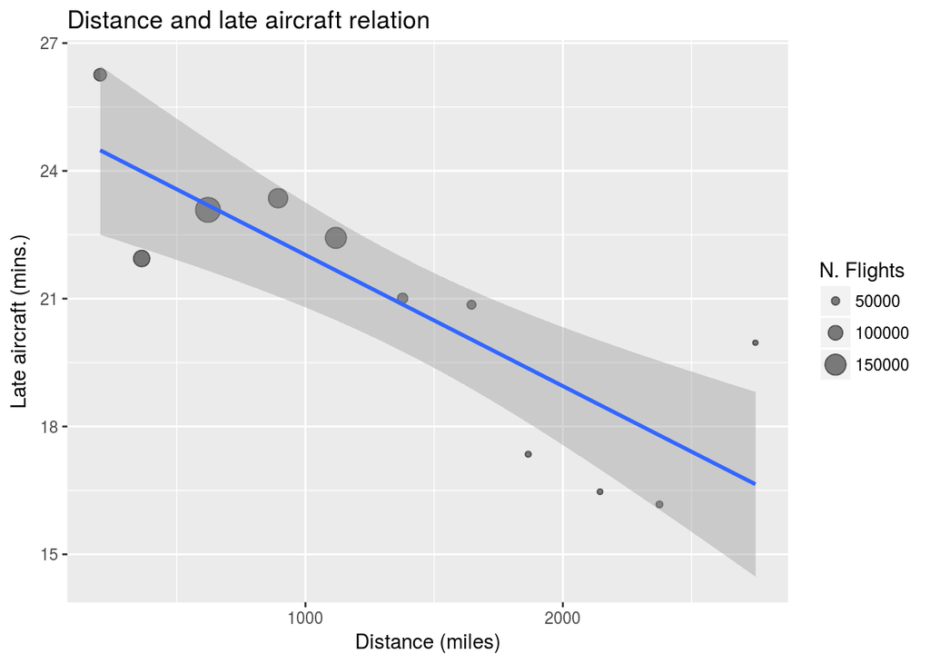

```r
ggplot(delay, aes(dist, lateCraft)) +
  geom_point(aes(size = count), alpha = 1/2) +
  labs(x="Distance (miles)", y="Late aircraft (mins.)") +
  geom_smooth(method = 'glm') +
  scale_size_area() +
  ggtitle("Distance and late aircraft relation") +
  scale_radius(name="N. Flights")
```

In this final plot, we can see that a late aircraft delay is more common in shorter flights than in long flights. Why? Checking the departure/arrival performance features in the dataset we find TaxiOut and TaxiIn. These features are the minutes the aircraft takes to taxi from the terminal to the runway (TaxiOut) and the opposite (TaxiIn). Let’s check if the time of taxiing is significant with the delays caused by a late aircraft.

```r
taxi <- data_frame(perf_aa$LateAircraftDelay,perf_aa$TaxiOut+perf_aa$TaxiIn)
taxi <- taxi[complete.cases(taxi),]
colnames(taxi) <- c("delay","taxi")
summary(glm(data=taxi,delay~.))
```

```
##
## Call:
## glm(formula = delay ~ ., data = taxi)
##
## Deviance Residuals:
##     Min       1Q   Median       3Q      Max
##  -33.15   -23.52   -15.31     3.56  1402.91
##
## Coefficients:
##              Estimate Std. Error t value Pr(>|t|)
## (Intercept) 34.579344   0.234719  147.32   <2e-16 ***
## taxi        -0.356866   0.005852  -60.99   <2e-16 ***
## ---
## Signif. codes:  0 '***' 0.001 '**' 0.01 '*' 0.05 '.' 0.1 ' ' 1
##
## (Dispersion parameter for gaussian family taken to be 2205.833)
##
##     Null deviance: 395219832  on 175452  degrees of freedom
## Residual deviance: 387015593  on 175451  degrees of freedom
## AIC: 1848706
##
## Number of Fisher Scoring iterations: 2
```

# San Antonio

As we saw, San Antonio is the airport with more departure delays for American Airlines. Let’s see how other carriers behave in this same airport. First, let’s get ready the data.

```r
ps_by_carrier <- rbind(perf,perf_aa) %>%
  filter(!is.na(CarrierDelay) &
           OriginCityName=="San Antonio, TX"
  ) %>%
  group_by( Carrier)
```

Now we will check how American Airlines and other carriers operate in San Antonio Airport.

## Flight distances

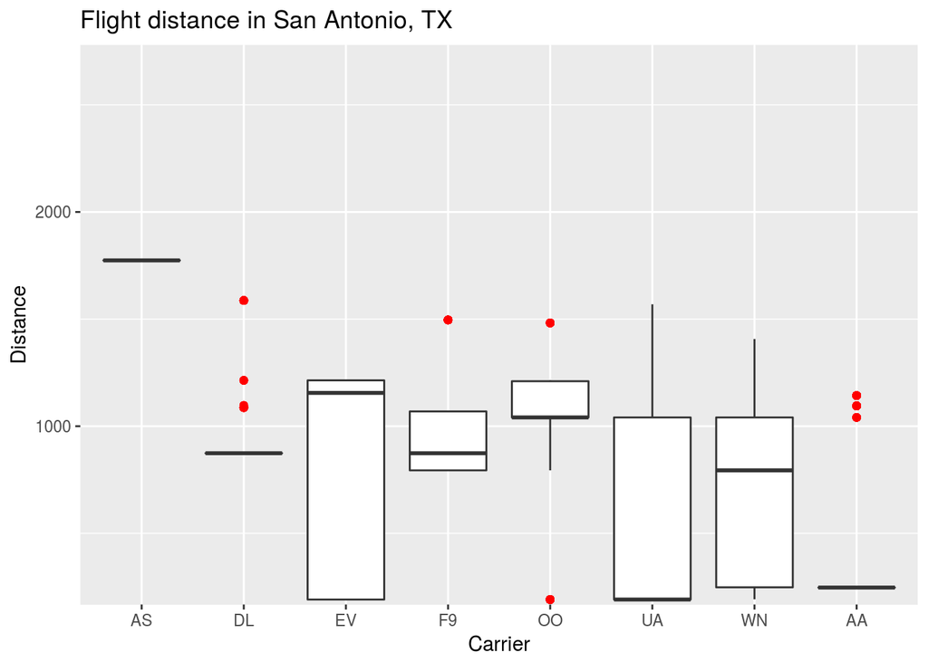

```r
pd <- ggplot(ps_by_carrier, aes(Carrier, Distance)) +
  geom_boxplot(outlier.colour = "red") +
  labs(x="Carrier",y="Distance") +
  ggtitle("Flight distance in San Antonio, TX")

ylim1 = boxplot.stats(ps_by_carrier$Distance)$stats[c(1, 5)]

pd <- pd + coord_cartesian(ylim = ylim1*1.5)

plot(pd)
```

American Airlines departure flights from San Antonio Airport are usually short flights.

## Departure delay

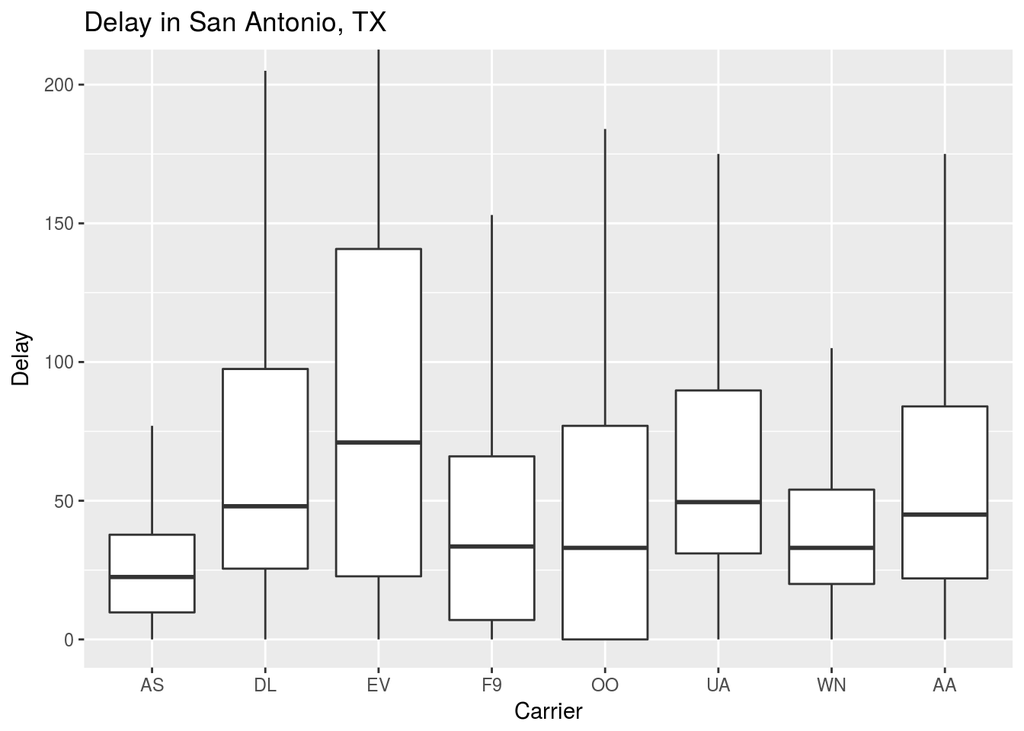

```r
p0 <- ggplot(ps_by_carrier, aes(Carrier, DepDelayMinutes)) +
  geom_boxplot(outlier.shape=NA) +
  labs(x="Carrier",y="Delay") +
  ggtitle("Delay in San Antonio, TX")

ylim1 = boxplot.stats(ps_by_carrier$DepDelayMinutes)$stats[c(1, 5)]

p0 <- p0 + coord_cartesian(ylim = ylim1*1.5)

plot(p0)
```

## Carrier delay

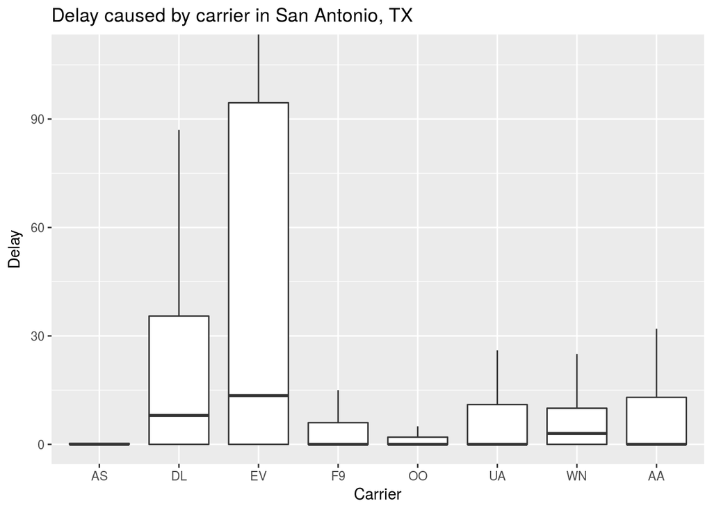

```r
p1 <- ggplot(ps_by_carrier, aes(Carrier, CarrierDelay)) +
  geom_boxplot(outlier.shape=NA) +
  labs(x="Carrier",y="Delay") +
  ggtitle("Delay caused by carrier in San Antonio, TX")

ylim1 = boxplot.stats(ps_by_carrier$CarrierDelay)$stats[c(1, 5)]

p1 <- p1 + coord_cartesian(ylim = ylim1*4)

plot(p1)
```

As we checked previously, with short flights the delays caused by the carrier are not very big. The results are consistent.

## Late aircraft

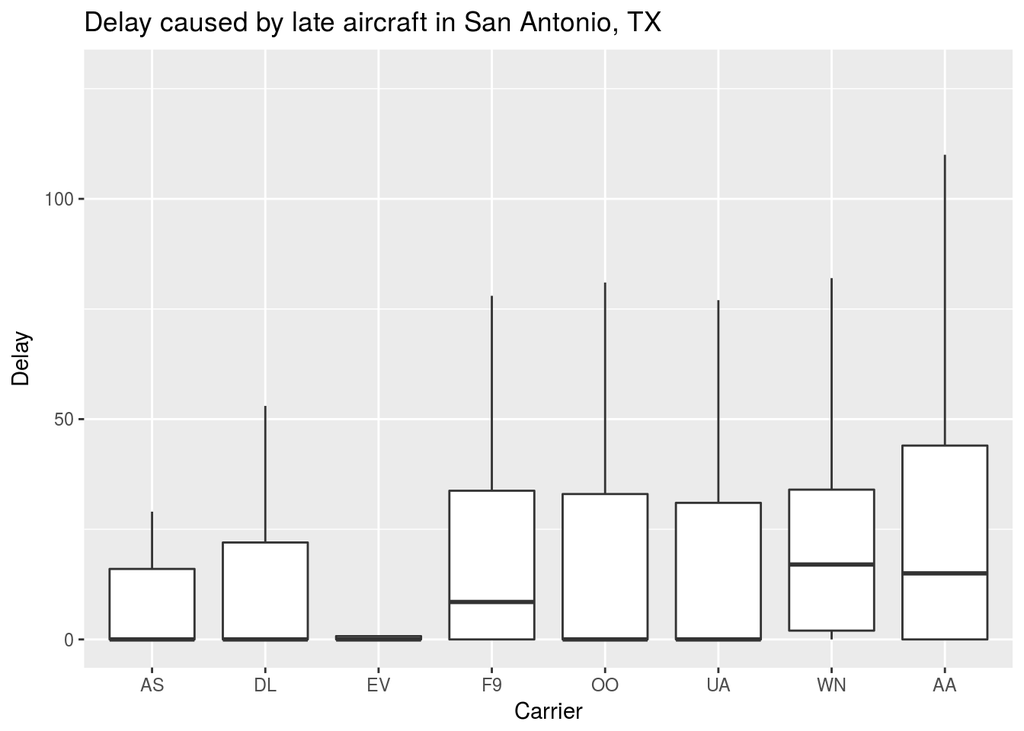

```r
p2 <- ggplot(ps_by_carrier, aes(Carrier, LateAircraftDelay)) +
  geom_boxplot(outlier.shape=NA) +
  labs(x="Carrier",y="Delay") +
  ggtitle("Delay caused by late aircraft in San Antonio, TX")

ylim1 = boxplot.stats(ps_by_carrier$LateAircraftDelay)$stats[c(1, 5)]

p2 <- p2 + coord_cartesian(ylim = ylim1*1.5)

plot(p2)
```

Again, American Airlines is one of the carriers with most delays caused by a late aircraft. This one can be explained again by the distance of the flights.

## Taxiing

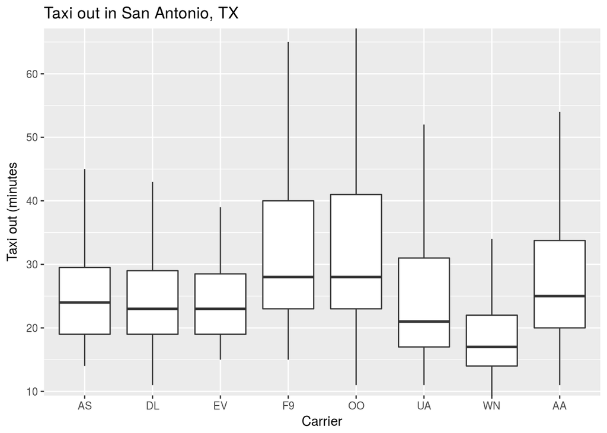

```r
p3 <- ggplot(ps_by_carrier, aes(Carrier, TaxiIn+TaxiOut)) +
  geom_boxplot(outlier.shape=NA) +
  labs(x="Carrier",y="Taxi out (minutes") +
  ggtitle("Taxi out in San Antonio, TX")

ylim1 = boxplot.stats(ps_by_carrier$TaxiIn+ps_by_carrier$TaxiOut)$stats[c(1, 5)]

p3 <- p3 + coord_cartesian(ylim = ylim1*1.5)

plot(p3)
```